# AE 24: Final Project in R Markdown - Report

Bora Jin

## Bulletin

Course evaluation is now open! It will be closed on Tuesday, June 21 at 11:59pm. If **more than 80%** of you complete the evaluation, everyone will receive **a bonus point**!

Check your emails or visit [duke.evaluationkit.com](https://duke.evaluationkit.com/) to complete the evaluation.

## Getting Started

- Clone the repository entitled “ae24-GitHubUsername” at [course GitHub organization page](https://github.com/sta199-summer22) on your [RStudio](https://vm-manage.oit.duke.edu/containers).
- Open the `.Rmd` file and replace “Your Name” with your name.

## Introduction

Refer to [STA199: Final Project - Tips](https://sta199-summer22.netlify.app/project/project-tips_bj) for general guidelines for formatting of your report.

## Text

In order to make bullet points, skip a line and use a hyphen `-`.

- *italic*
- **bold**
- `function` or `variable`
- [links](https://rmarkdown.rstudio.com/lesson-8.html)
  - `tab` once for a sub-list
  - **Q -** Knit the document to PDF and see how the link appears.
  - If you know your PDF will be printed, add `links-as-notes: TRUE` to YAML to display URLs as a footnote in the knitted PDF.
- Latex equations
  - inline: $y = \beta_0 + \beta_1x_1 + \epsilon$
  - chunk:
    $$\hat{y} = \hat{\beta}_0 + \hat{\beta}_1x_1$$
- The default font size is 10pt. You can increase it to 11pt or 12pt. In order to change the font size to 11pt, add `fontsize: 11pt` to YAML.

## Citation

Your report will include citations about the data source, previous research, and other sources as needed. At a minimum, you should have a citation for the data source.

Follow the steps below to easily include citations in your report:

1. Prepare a `.bib` file. All of your bibliography entries will be stored in it. Let’s take a look at `references.bib`.

**Q -** Add a bibliography entry for the book *R markdown: The definitive guide* to `references.bib`.

Here are examples of different in-text citations:

- In @gorman2014structural, the authors focus on the analysis of Adelie penguins.
- Studies have shown whether environmental variability in the form of winter sea ice is associated with differences in male and female pre-breeding foraging niche [@gorman2014structural].

**Q -** Add a citation for *R markdown: The definitive guide* in the sentence below.

## Options for Code Chunks

Code chunk options are used to customize how the code and output is displayed in the knitted R Markdown document. There are two ways to set code chunk options:

- In the header of an individual code chunk
- As a global setting to apply to all code chunks

A few options to change what we show / hide in the knitted document:

- `message = FALSE` to hide messages.
- `warning = FALSE` to hide warnings (with caution!)
  - While you conduct analyses, you should know what warning messages you receive and decide if it is okay to ignore them. For the final knitting, you may use `warning = FALSE`.
- `echo = FALSE` to hide code.
  - For the project, you will set the option `echo = FALSE` to hide all code in your final report.
- `include = FALSE` to run code but hide code, output, messages, warnings, etc.
  - Avoid using this option as a global setting.
- `eval = FALSE` to not run code.
  - Useful when your code chunk is incomplete. You should not have any incomplete code chunks in your final report!

**Q -** Clean up the mess below.

```r
knitr::opts_chunk$set(message = TRUE,
                      warning = TRUE,
                      echo = TRUE,
                      fig.width = 6, # width of figure
                      fig.asp = .618, # aspect ratio of figure
                      out.width = "70%", # width relative to text
                      fig.align = "center" # figure alignment
                      )
```

```r
library(knitr)
library(tidyverse)
theme_set(theme_bw()) # set global theme
```

**Q -** Try `echo = FALSE` and take a look at the updated PDF.

## Theme for Plotting

For `ggplots`, you can set a global theme (see the code chunk above). Click [here](https://ggplot2.tidyverse.org/reference/ggtheme.html) to explore available themes and choose your favorite. In case your PDF is printed, gray or dark background for plots are not recommended.

## Customizing Plots

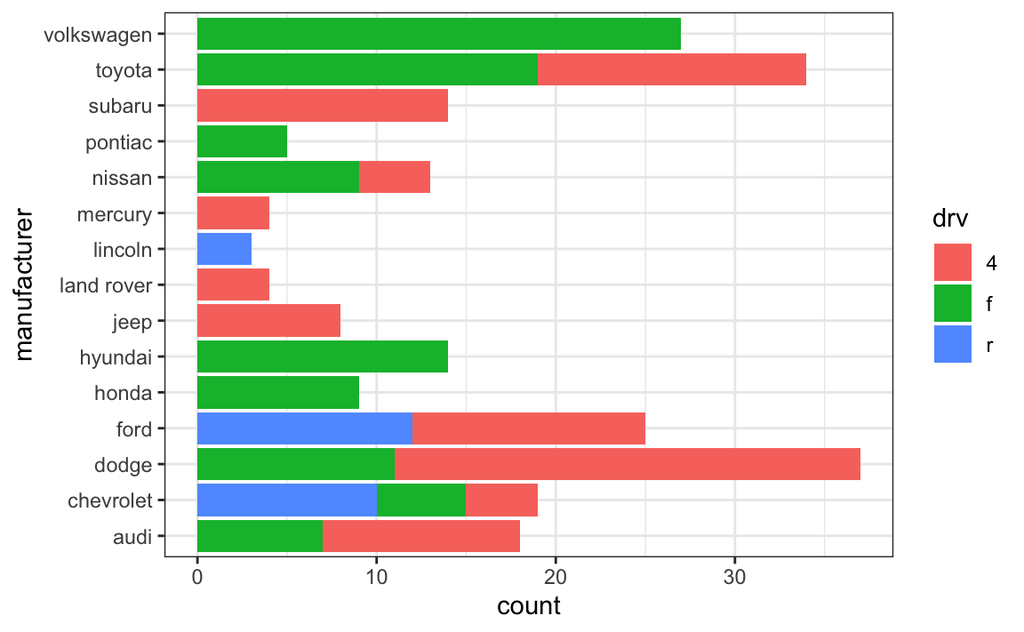

```r
mpg %>%
  ggplot(aes(y = manufacturer, fill = drv)) +
  geom_bar()
```

We can do better than this.

**Q -** Incorporate the following recommended changes in the plot.

- Axes labels begin with a capital letter.
- The title of the fill legend is “The type of drive train”.
- The levels of the fill legend are “front-wheel” for “f”, “rear-wheel” for “r”, and “four-wheel” for “4” in written order.
- Use fill colors from `my_palette`.
- Manufacturer names begin with a capital letter.
- Shorter bars locate on top.
- Add a caption “Counts of the type of drive train by manufacturer”.

## Customizing Tables

Calculate mean, median, and standard deviation of `cty`.

```r
mpg %>%
  summarize(mean_cty = mean(cty), median_cty = median(cty), sd_cty = sd(cty))
```

```
## # A tibble: 1 × 3
##   mean_cty median_cty sd_cty
##      <dbl>      <dbl>  <dbl>
## 1     16.9         17   4.26
```

We can also do better than this.

**Q -** Incorporate the following recommended changes in the table.

- Print it as a nice table.
- Results are rounded to 3 decimal places.
- Column names are “mean mpg”, “median mpg”, “sd of mpg”.
- Add a caption “Summary statistics of city miles per gallon (mpg) in city”.

## Acknowledgements

These notes were adapted from the following:

- [Markdown Basics](https://rmarkdown.rstudio.com/lesson-8.html)
- [Communicating data analysis](https://sta-212-f19.netlify.app/slides/lec-slides/15-communicating-data-analysis.html#1) by Dr. Lucy McGowan
- [Customizing R Markdown](https://rladiesstl.github.io/intro-meetup4-oct-2021/customize-rmd.html#1) by Dr. Mine Çetinkaya-Rundel
- [Take a sad plot and make it better](https://alison.netlify.app/rlm-sad-plot-better/#1) by Dr. Alison Hill